# QK Box 10.10

Singh et al. (2016) examined the response of copulatory traits in male fruitflies (*Drosophila melanogaster*) to cold stress. They had two selection treatments (populations selected for cold shock versus control populations, a fixed effect) crossed with five ancestral populations that experimental flies were derived from (random effect). The data we will analyse are from an experiment that compared files from the two selection treatments that were cold shocked, allowed to recover and then copulatory traits were measured after 4, 12 and 30 hours. Different flies were used for each period so there are no repeated measures. This fully-crossed design has two fixed effects (selection treatment, period) and one random effect (ancestral population, termed “block” by Singh et al. (2016), the sample size varied from 35 to 62 flies in each combination of selection treatment, period and ancestral population, and the response variable we will focus on was mating latency (minutes).

The paper is [here](https://doi.org/10.1371/journal.pone.0153629)

Singh, K., Samant, M. A., Tom, M. T. & Prasad, N. G. (2016). Evolution of pre- and post-copulatory traits in male *Drosophila melanogaster* as a correlated response to selection for resistance to cold stress. *PLoS One*, 11, e0153629.

### Preliminaries

First, load the required packages (afex, car, lattice, lme4, lmerTest, nlme, VCA, Rmisc, MuMin, emmeans)

Import singh data file (singh.csv)

```r
singh <- read.csv("../data/singh.csv")
head(singh,5)
```

|  | selection | period | block | matlat |
| --- | --- | --- | --- | --- |
| 1 | FSB | 4 | 1 | 3 |
| 2 | FSB | 4 | 1 | 2 |
| 3 | FSB | 4 | 1 | 9 |
| 4 | FSB | 4 | 1 | 18 |
| 5 | FSB | 4 | 1 | 6 |

Set contrasts from afex

Convert period and block to factors

```r
set_sum_contrasts()
```

```
## setting contr.sum globally: options(contrasts=c('contr.sum', 'contr.poly'))
```

```r
singh$block <- factor(singh$block)
singh$period <- factor(singh$period)
```

### Diagnostics

Check assumptions with boxplots - very skewed distributions

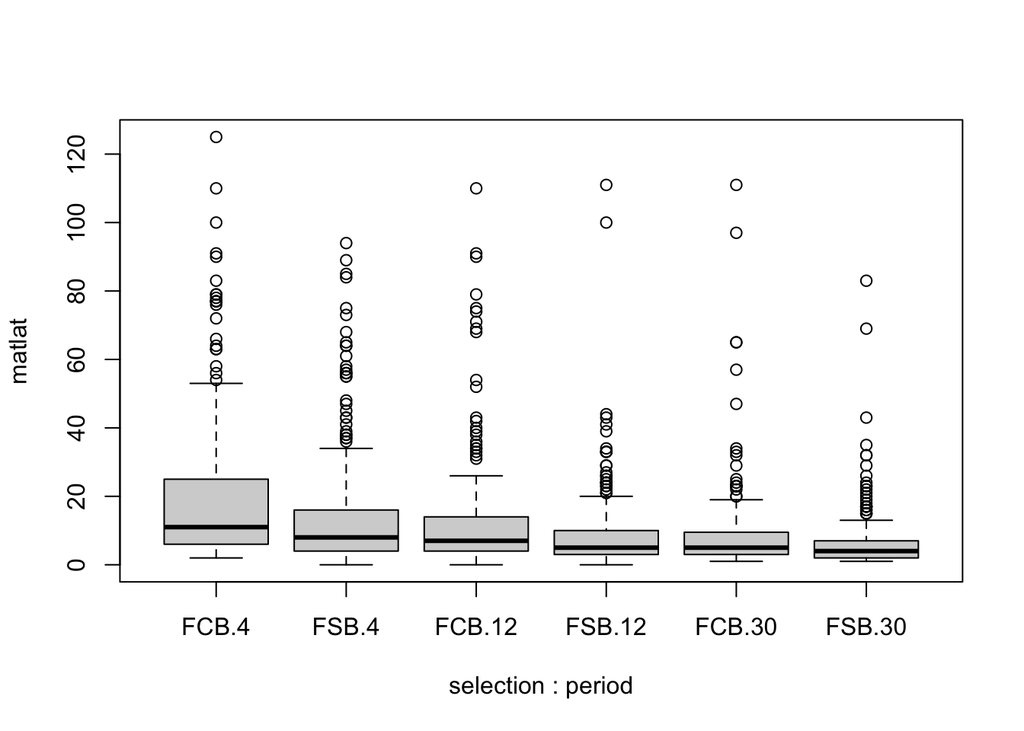

```r
boxplot(matlat~selection*period, data=singh)
```

Fit OLS anova model to check residuals

```r
singh.aov <- aov(matlat~selection*period*block, data=singh)
```

Check residuals - variance increases with mean

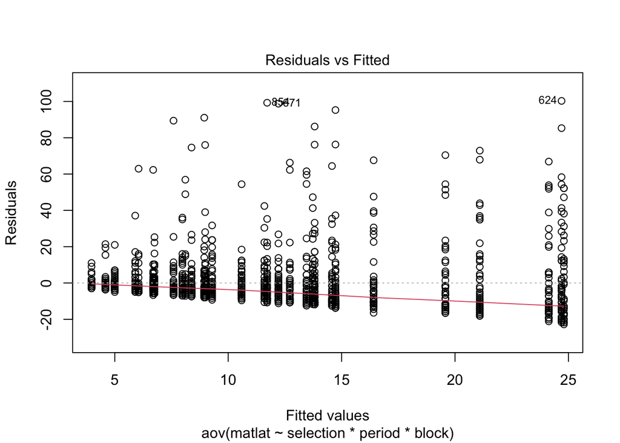

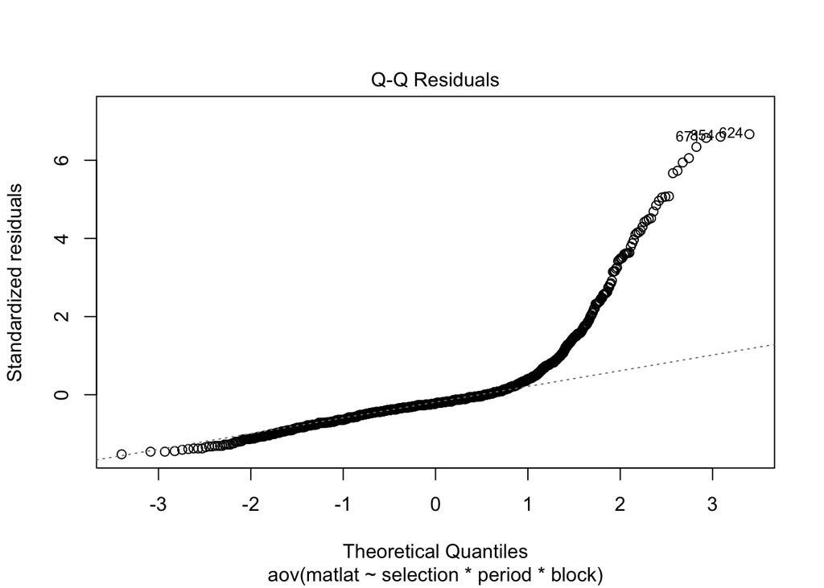

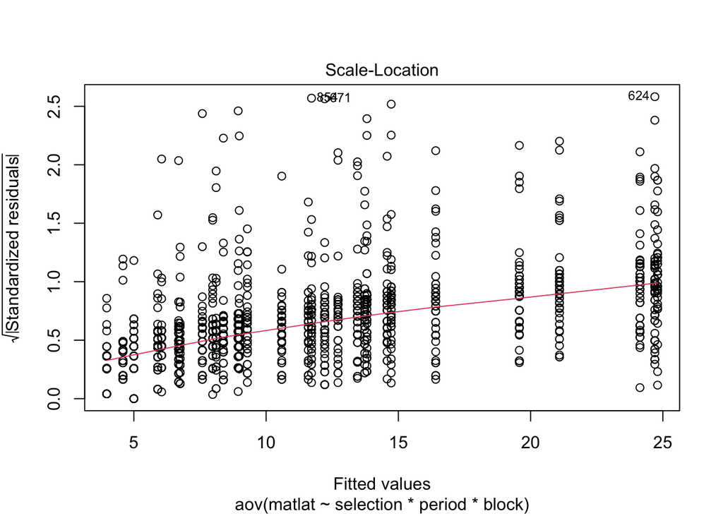

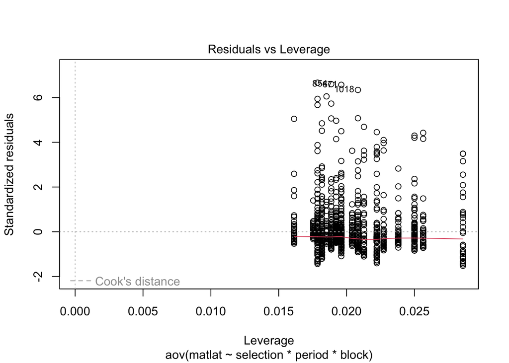

```r
plot(singh.aov)
```

Transform response to logs (+1 to handle zero values)

```r
singh$lmatlat <- log10(singh$matlat+1)
```

Check assumptions - much improved boxplots

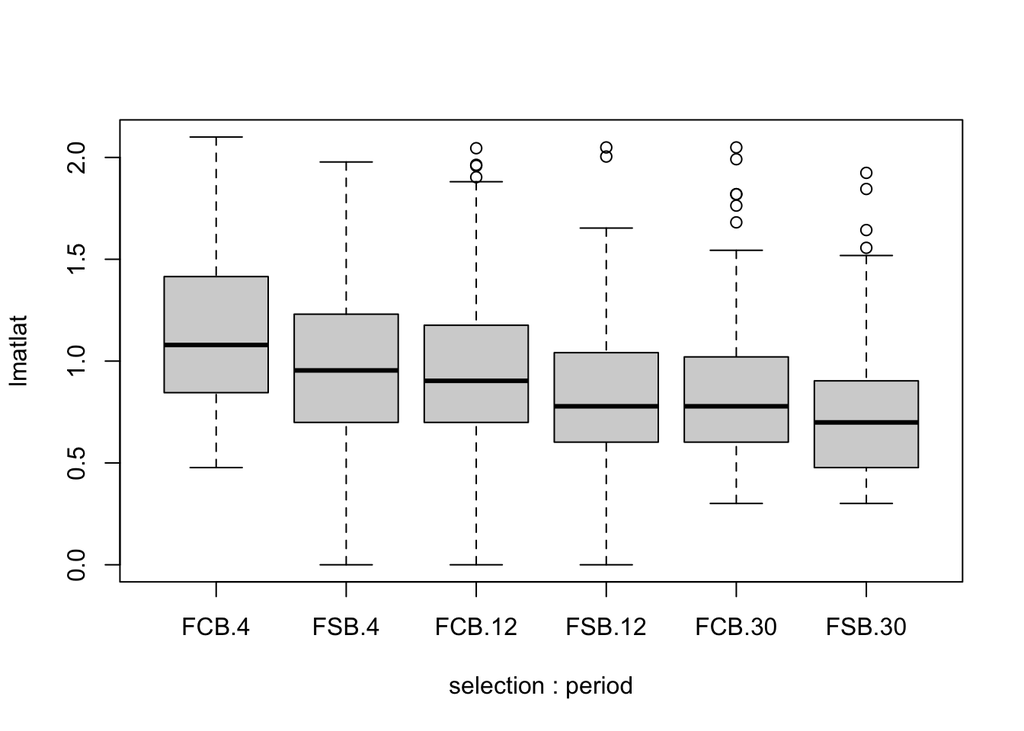

```r
boxplot(lmatlat~selection*period, data=singh)
```

Refit OLS model and check residuals (much better)

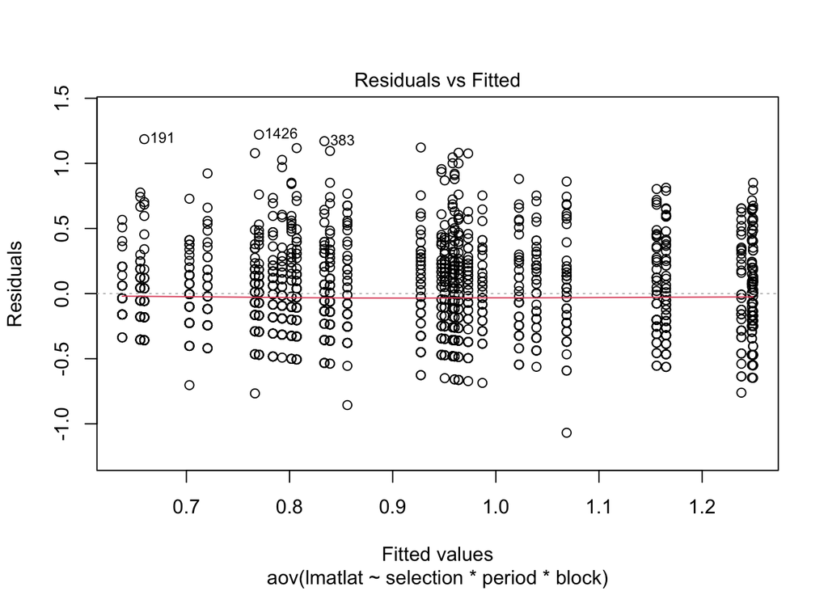

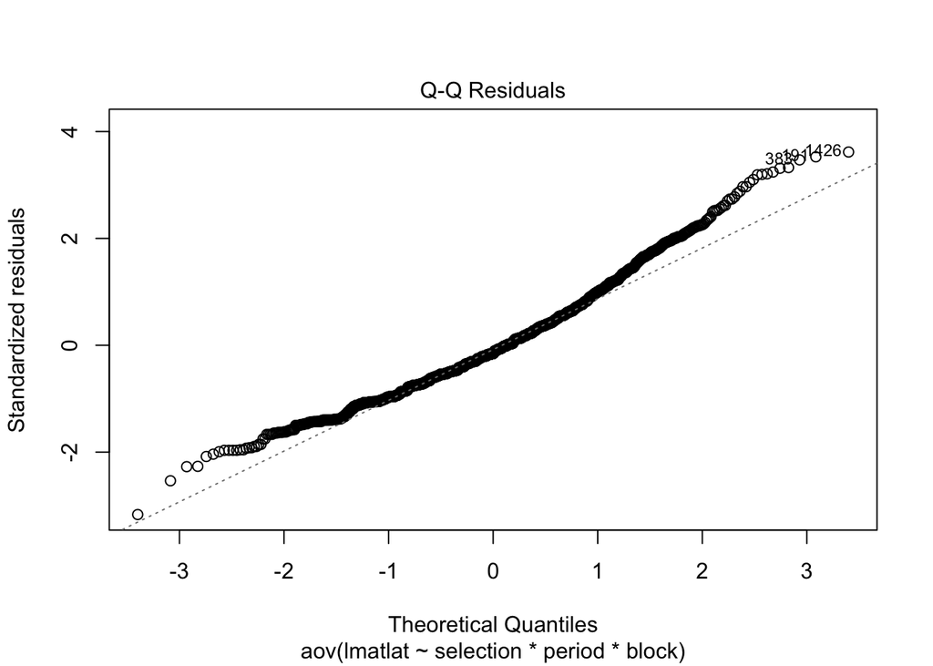

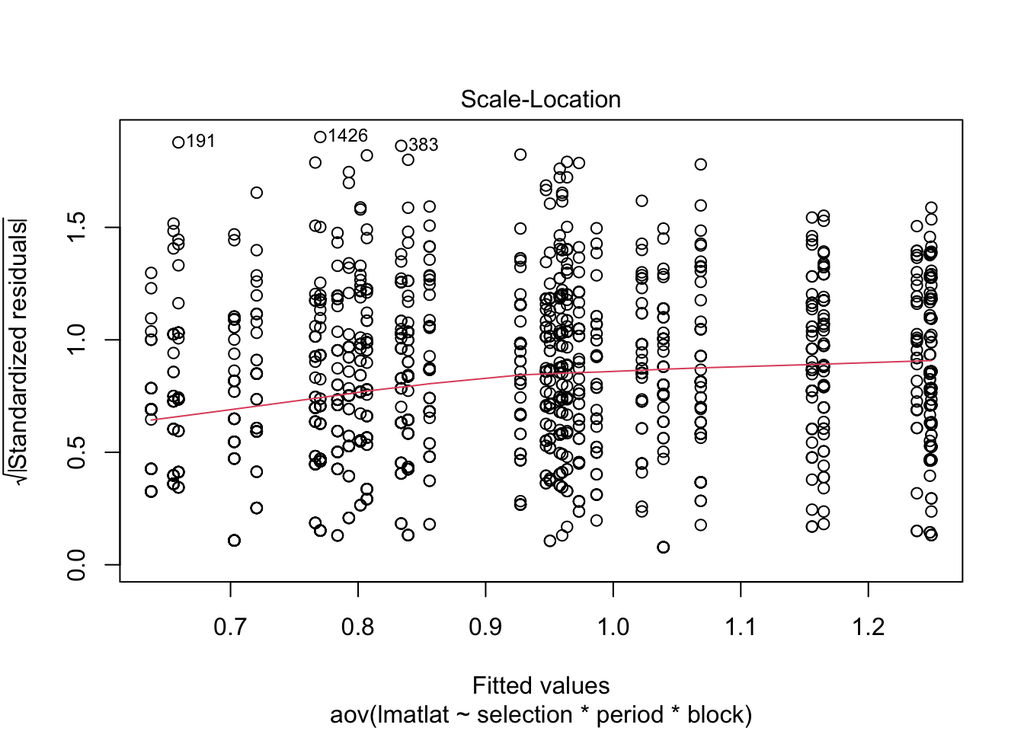

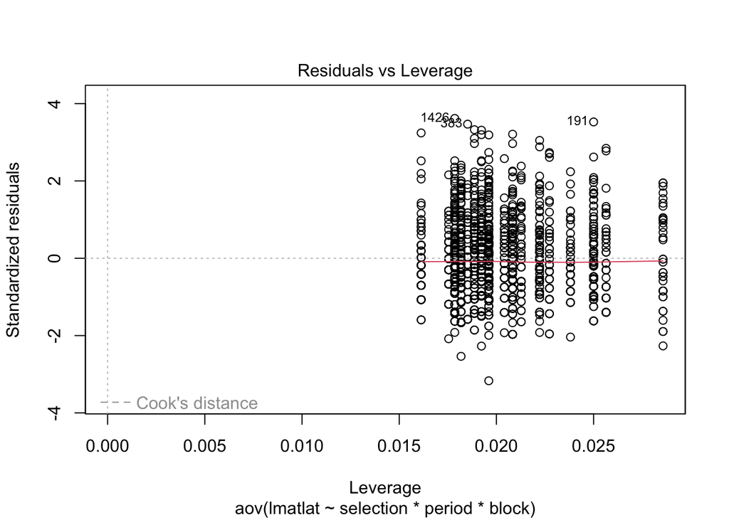

```r
singh.aov1 <- aov(lmatlat~selection*period*block, data=singh)
plot(singh.aov1)
```

### Use transformed data

Although the original paper used untransformed data, our pre-analysis checks suggest that a data transformation, or, as in later chapters, a generalized linear model, might be a better fit

### Fit lm models to get type III SS using car

```r
singh.lm1 <- lm(lmatlat ~ selection*period*block, data=singh)
summary(singh.lm1)
```

```
##
## Call:
## lm(formula = lmatlat ~ selection * period * block, data = singh)
##
## Residuals:
##      Min       1Q   Median       3Q      Max
## -1.06862 -0.24337 -0.05324  0.18892  1.22087
##
## Coefficients:
##                             Estimate Std. Error t value Pr(>|t|)
## (Intercept)                9.160e-01  8.936e-03 102.505  < 2e-16 ***
## selection1                 5.832e-02  8.936e-03   6.526 9.32e-11 ***
## period1                    1.628e-01  1.269e-02  12.829  < 2e-16 ***
## period2                   -1.722e-02  1.260e-02  -1.367 0.171925
## block1                    -7.794e-02  1.886e-02  -4.133 3.78e-05 ***
## block2                     6.642e-02  1.815e-02   3.659 0.000262 ***
## block3                     1.103e-01  1.739e-02   6.345 2.96e-10 ***
## block4                     3.516e-02  1.785e-02   1.970 0.049085 *
## selection1:period1         6.085e-03  1.269e-02   0.479 0.631697
## selection1:period2         6.948e-03  1.260e-02   0.552 0.581364
## selection1:block1         -2.723e-02  1.886e-02  -1.444 0.148878
## selection1:block2          1.771e-02  1.815e-02   0.976 0.329425
## selection1:block3          2.615e-02  1.739e-02   1.504 0.132784
## selection1:block4         -7.886e-03  1.785e-02  -0.442 0.658727
## period1:block1            -9.683e-03  2.671e-02  -0.362 0.717042
## period2:block1             5.370e-02  2.636e-02   2.037 0.041791 *
## period1:block2             5.627e-02  2.611e-02   2.155 0.031331 *
## period2:block2            -5.488e-02  2.557e-02  -2.146 0.032035 *
## period1:block3            -3.017e-02  2.451e-02  -1.231 0.218594
## period2:block3             5.537e-02  2.487e-02   2.227 0.026122 *
## period1:block4             2.980e-02  2.549e-02   1.169 0.242490
## period2:block4            -2.405e-02  2.498e-02  -0.963 0.335852
## selection1:period1:block1 -5.946e-03  2.671e-02  -0.223 0.823905
## selection1:period2:block1  3.469e-02  2.636e-02   1.316 0.188293
## selection1:period1:block2 -4.560e-02  2.611e-02  -1.746 0.080981 .
## selection1:period2:block2 -6.377e-03  2.557e-02  -0.249 0.803106
## selection1:period1:block3 -1.761e-04  2.451e-02  -0.007 0.994268
## selection1:period2:block3 -7.585e-05  2.487e-02  -0.003 0.997567
## selection1:period1:block4  4.795e-02  2.549e-02   1.881 0.060151 .
## selection1:period2:block4 -3.488e-03  2.498e-02  -0.140 0.888953
## ---
## Signif. codes:  0 '***' 0.001 '**' 0.01 '*' 0.05 '.' 0.1 ' ' 1
##
## Residual standard error: 0.3406 on 1449 degrees of freedom
## Multiple R-squared:  0.2076, Adjusted R-squared:  0.1917
## F-statistic: 13.09 on 29 and 1449 DF,  p-value: < 2.2e-16
```

```r
Anova(singh.lm1, type='III')
```

|  | Sum Sq | Df | F value | Pr(>F) |
| --- | --- | --- | --- | --- |
| (Intercept) | 1218.9845466 | 1 | 1.050720e+04 | 0.000000e+00 |
| selection | 4.9407712 | 1 | 4.258764e+01 | 9.319096e-11 |
| period | 23.0736398 | 2 | 9.944317e+01 | 3.390402e-41 |
| block | 12.8477643 | 4 | 2.768576e+01 | 3.521857e-22 |
| selection:period | 0.1238948 | 2 | 5.339638e-01 | 5.863918e-01 |
| selection:block | 0.5312213 | 4 | 1.144733e+00 | 3.337623e-01 |
| period:block | 2.5399787 | 8 | 2.736711e+00 | 5.350503e-03 |
| selection:period:block | 1.1445725 | 8 | 1.233224e+00 | 2.755175e-01 |
| Residuals | 168.1045821 | 1449 | NA | NA |

Get correct F-ratio and P value for selection x period

```r
f = 0.03/0.14
f
```

```
## [1] 0.2142857
```

```r
1-pf(f, 2, 8, lower.tail = TRUE, log.p = FALSE)
```

```
## [1] 0.8116038
```

Get correct F-ratio and P value for selection

```r
f = 4.72/0.13
f
```

```
## [1] 36.30769
```

```r
1-pf(f, 1, 4, lower.tail = TRUE, log.p = FALSE)
```

```
## [1] 0.003822431
```

Get correct F-ratio and P value for period

```r
f = 11.09/0.33
f
```

```
## [1] 33.60606
```

```r
1-pf(f, 2, 8, lower.tail = TRUE, log.p = FALSE)
```

```
## [1] 0.0001279996
```

#### Use VCA package to get anova var comps - unreliable sue to imbalance in sample sizes

```r
singh.vca <- anovaMM(lmatlat~selection + period + selection*period + (block) + (selection*block) + (period*block) + (selection*period*block), singh)
```

```
## Convert variable selection from "character" to "factor"!
```

```r
VCAinference(singh.vca, alpha=0.05, VarVC=TRUE, excludeNeg=FALSE, constrainCI=FALSE)
```

```
##
##
##
## Inference from Mixed Model Fit
## ------------------------------
##
## > VCA Result:
## -------------
##
##  [Fixed Effects]
##
##                   int          selectionFCB          selectionFSB
##                0.7235                0.0967                0.0000
##               period4              period12              period30
##                0.2906                0.1100                0.0000
##  selectionFCB:period4  selectionFSB:period4 selectionFCB:period12
##                0.0332                0.0000                0.0322
## selectionFSB:period12 selectionFCB:period30 selectionFSB:period30
##                0.0000                0.0000                0.0000
##
##
##  [Variance Components]
##
##   Name                   DF       SS       MS     VC     %Total  SD     CV[%]
## 1 total                  419.9978                 0.1282 100     0.358  39.263
## 2 block                  4        12.7393  3.1848 0.0097 7.5916  0.0986 10.8181
## 3 selection:block        4        0.523    0.1307 0*     0*      0*     0*
## 4 period:block           8        2.6243   0.328  0.0019 1.4688  0.0434 4.7585
## 5 selection:period:block 8        1.1446   0.1431 6e-04  0.4328  0.0236 2.5829
## 6 error                  1449     168.1046 0.116  0.116  90.5068 0.3406 37.3529
##   Var(VC)
## 1 1e-04
## 2 1e-04
## 3 0
## 4 0
## 5 0
## 6 0
##
## Mean: 0.9119 (N = 1479)
##
```

[output cut: 21 more lines]

```
## error                  0.3406   0.3286 0.3535 0.3305        0.3514
##
## > CV[%]:
## --------
##                        Estimate CI LCL  CI UCL  One-Sided LCL One-Sided UCL
## total                  39.263   36.778  42.111  37.164        41.6359
## block                  10.8181  0*      17.2708 0*            16.4055
## selection:block        0        0*      4.3363  0*            3.9724
## period:block           4.7585   0*      8.1098  0*            7.6705
## selection:period:block 2.5829   0*      6.4271  0*            5.9782
## error                  37.3529  36.0412 38.7644 36.2481       38.533
##
##
## 95% Confidence Level  | * CI-limits constrained to be >= 0
## SAS PROC MIXED method used for computing CIs
```

Get least squares means for selection and period

```r
emmeans (singh.lm1, "selection")
```

```
## NOTE: Results may be misleading due to involvement in interactions
```

```
##  selection emmean     SE   df lower.CL upper.CL
##  FCB        0.974 0.0130 1449    0.949    1.000
##  FSB        0.858 0.0123 1449    0.834    0.882
##
## Results are averaged over the levels of: period, block
## Confidence level used: 0.95
```

```r
emmeans(singh.lm1, "period")
```

```
## NOTE: Results may be misleading due to involvement in interactions
```

```
##  period emmean     SE   df lower.CL upper.CL
##  4       1.079 0.0156 1449    1.048    1.109
##  12      0.899 0.0154 1449    0.869    0.929
##  30      0.770 0.0154 1449    0.740    0.801
##
## Results are averaged over the levels of: selection, block
## Confidence level used: 0.95
```

### Backtransform values

FCB & FSB:

```r
#means
10^.974
```

```
## [1] 9.418896
```

```r
10^.858
```

```
## [1] 7.211075
```

```r
#lower CIs
10^.949
```

```
## [1] 8.892011
```

```r
10^ .834
```

```
## [1] 6.823387
```

```r
#upper CIs
10^1
```

```
## [1] 10
```

```r
10^.882
```

```
## [1] 7.62079
```

Periods

```r
10^1.079
```

```
## [1] 11.99499
```

```r
10^.899
```

```
## [1] 7.925013
```

```r
10^.77
```

```
## [1] 5.888437
```

## Fit mixed effects model using REML

```r
singh.lmer1 <- lmer(lmatlat~selection + period +selection:period + (1|block) + (1|selection:block)
            + (1|period:block) + (1|selection:period:block), REML=TRUE, singh)
```

```
## boundary (singular) fit: see help('isSingular')
```

```r
summary(singh.lmer1, ddf="Kenward-Roger")
```

```
## Linear mixed model fit by REML. t-tests use Kenward-Roger's method [
## lmerModLmerTest]
## Formula: lmatlat ~ selection + period + selection:period + (1 | block) +
##     (1 | selection:block) + (1 | period:block) + (1 | selection:period:block)
##    Data: singh
##
## REML criterion at convergence: 1072.5
##
## Scaled residuals:
##     Min      1Q  Median      3Q     Max
## -3.2186 -0.7061 -0.1176  0.5581  3.6662
##
## Random effects:
##  Groups                 Name        Variance  Std.Dev.
##  selection:period:block (Intercept) 0.0004728 0.02174
##  period:block           (Intercept) 0.0018763 0.04332
##  selection:block        (Intercept) 0.0000000 0.00000
##  block                  (Intercept) 0.0093284 0.09658
##  Residual                           0.1160296 0.34063
## Number of obs: 1479, groups:
## selection:period:block, 30; period:block, 15; selection:block, 10; block, 5
##
## Fixed effects:
##                     Estimate Std. Error        df t value Pr(>|t|)
## (Intercept)         0.916339   0.045676  4.000645  20.062 3.64e-05 ***
## selection1          0.059218   0.009772  3.959330   6.060  0.00387 **
## period1             0.162751   0.021026  8.026933   7.740 5.43e-05 ***
## period2            -0.018352   0.020977  7.978608  -0.875  0.40721
## selection1:period1  0.005709   0.013845  7.978136   0.412  0.69092
## selection1:period2  0.005194   0.013774  7.904829   0.377  0.71601
## ---
## Signif. codes:  0 '***' 0.001 '**' 0.01 '*' 0.05 '.' 0.1 ' ' 1
##
## Correlation of Fixed Effects:
##             (Intr) slctn1 perid1 perid2 slc1:1
## selection1   0.010
## period1      0.001  0.005
## period2     -0.001  0.011 -0.500
## slctn1:prd1  0.001  0.007  0.033 -0.026
## slctn1:prd2  0.004 -0.004 -0.026  0.038 -0.501
## optimizer (nloptwrap) convergence code: 0 (OK)
## boundary (singular) fit: see help('isSingular')
```

```r
anova(singh.lmer1, ddf="Kenward-Roger")
```

|  | Sum Sq | Mean Sq | NumDF | DenDF | F value | Pr(>F) |
| --- | --- | --- | --- | --- | --- | --- |
| selection | 4.26071650 | 4.26071650 | 1 | 3.959330 | 36.7209432 | 0.0038693960 |
| period | 8.34389274 | 4.17194637 | 2 | 7.997415 | 35.9558623 | 0.0001006247 |
| selection:period | 0.07259196 | 0.03629598 | 2 | 7.922821 | 0.3128161 | 0.7400191951 |

### CI on REML variance components (remembering to square CIs from lmer with are in SD units)

```r
singh.ci1 <- confint.merMod(singh.lmer1, oldNames=FALSE)
```

```
## Computing profile confidence intervals ...
```

[output not shown]

```r
singh.vc1 <- (singh.ci1)^2
print(singh.vc1)
```

```
##                                              2.5 %       97.5 %
## sd_(Intercept)|selection:period:block 0.000000e+00 0.0028115042
## sd_(Intercept)|period:block           5.038698e-05 0.0061109797
## sd_(Intercept)|selection:block        0.000000e+00 0.0025719838
## sd_(Intercept)|block                  2.099964e-03 0.0386315011
## sigma                                 1.079706e-01 0.1247963866
## (Intercept)                           6.675498e-01 1.0291062846
## selection1                            1.759695e-03 0.0058974621
## period1                               1.497753e-02 0.0416266940
## period2                               3.518000e-03 0.0005001096
## selection1:period1                    3.642308e-04 0.0009196359
## selection1:period2                    3.889608e-04 0.0008685182
```

### Refit model omitting three way interaction to deal with singular fit

```r
singh.lmer2 <- lmer(lmatlat~selection + period +selection:period + (1|block) + (1|selection:block)
                     + (1|period:block), REML=TRUE, singh)
```

Compare models

```r
anova(singh.lmer1, singh.lmer2)
```

```
## refitting model(s) with ML (instead of REML)
```

|  | npar | AIC | BIC | logLik | deviance | Chisq | Df | Pr(>Chisq) |
| --- | --- | --- | --- | --- | --- | --- | --- | --- |
| singh.lmer2 | 10 | 1054.26 | 1107.252 | -517.1302 | 1034.26 | NA | NA | NA |
| singh.lmer1 | 11 | 1056.26 | 1114.551 | -517.1302 | 1034.26 | 0 | 1 | 1 |

```r
AICc(singh.lmer1, singh.lmer2)
```

|  | df | AICc |
| --- | --- | --- |
| singh.lmer1 | 11 | 1094.718 |
| singh.lmer2 | 10 | 1092.863 |

Omitting the interaction has little effect on fit

### Get results from this reduced model

```r
summary(singh.lmer2, ddf="Kenward-Roger")
```

```
## Linear mixed model fit by REML. t-tests use Kenward-Roger's method [
## lmerModLmerTest]
## Formula: lmatlat ~ selection + period + selection:period + (1 | block) +
##     (1 | selection:block) + (1 | period:block)
##    Data: singh
##
## REML criterion at convergence: 1072.7
##
## Scaled residuals:
##     Min      1Q  Median      3Q     Max
## -3.2217 -0.7051 -0.1208  0.5532  3.6705
##
## Random effects:
##  Groups          Name        Variance  Std.Dev.
##  period:block    (Intercept) 2.125e-03 0.046096
##  selection:block (Intercept) 8.772e-05 0.009366
##  block           (Intercept) 9.294e-03 0.096405
##  Residual                    1.162e-01 0.340852
## Number of obs: 1479, groups:  period:block, 15; selection:block, 10; block, 5
##
## Fixed effects:
##                      Estimate Std. Error         df t value Pr(>|t|)
## (Intercept)         9.164e-01  4.571e-02  4.001e+00  20.051 3.65e-05 ***
## selection1          5.935e-02  9.408e-03  3.952e+00   6.308  0.00336 **
## period1             1.629e-01  2.106e-02  8.028e+00   7.737 5.44e-05 ***
## period2            -1.854e-02  2.101e-02  7.982e+00  -0.882  0.40350
## selection1:period1  5.783e-03  1.262e-02  1.463e+03   0.458  0.64691
## selection1:period2  4.890e-03  1.256e-02  1.462e+03   0.389  0.69716
## ---
## Signif. codes:  0 '***' 0.001 '**' 0.01 '*' 0.05 '.' 0.1 ' ' 1
##
## Correlation of Fixed Effects:
##             (Intr) slctn1 perid1 perid2 slc1:1
## selection1   0.010
## period1      0.001  0.005
## period2     -0.001  0.011 -0.500
## slctn1:prd1  0.002  0.008  0.036 -0.028
## slctn1:prd2  0.004 -0.004 -0.028  0.041 -0.502
```

F tests of fixed effects (Type III SS) for this new model - same conclusions as above

```r
anova(singh.lmer2, ddf="Kenward-Roger")
```

|  | Sum Sq | Mean Sq | NumDF | DenDF | F value | Pr(>F) |
| --- | --- | --- | --- | --- | --- | --- |
| selection | 4.62278478 | 4.62278478 | 1 | 3.952389 | 39.789757 | 0.0033620634 |
| period | 8.33913004 | 4.16956502 | 2 | 8.000131 | 35.888739 | 0.0001011111 |
| selection:period | 0.08394443 | 0.04197222 | 2 | 1461.760209 | 0.361268 | 0.6968544269 |

#### Calculate CIs on var component for this new model

```r
singh.ci2 <- confint.merMod(singh.lmer2, oldNames=FALSE)
```

```
## Computing profile confidence intervals ...
```

```r
singh.vc2 <- (singh.ci2)^2
print(singh.vc2)
```

```
##                                       2.5 %       97.5 %
## sd_(Intercept)|period:block    4.289388e-05 0.0061855553
## sd_(Intercept)|selection:block 0.000000e+00 0.0026054634
## sd_(Intercept)|block           1.998556e-03 0.0386325700
## sigma                          1.079676e-01 0.1248031451
## (Intercept)                    6.695593e-01 1.0292268039
## selection1                     1.500194e-03 0.0062941098
## period1                        1.497466e-02 0.0415167809
## period2                        3.495238e-03 0.0004898233
## selection1:period1             3.647019e-04 0.0009201909
## selection1:period2             3.889714e-04 0.0008685996
```

## Analysis using untransformed response

This is the approach used by the paper’s author’s. We’ve given the initial OLS fit, which you can adjust for the random effects by recalculating F-ratios as shown in the earlier code. You can easily also run the REML mixed effects model.

```r
options(digits=4)
singh.lm2 <- lm(matlat~selection*period*block, data=singh)
summary(singh.lm2)
```

```
##
## Call:
## lm(formula = matlat ~ selection * period * block, data = singh)
##
## Residuals:
##    Min     1Q Median     3Q    Max
## -22.80  -6.94  -3.38   1.22 100.30
##
## Coefficients:
##                           Estimate Std. Error t value Pr(>|t|)
## (Intercept)                11.9362     0.3983   29.97  < 2e-16 ***
## selection1                  2.0177     0.3983    5.07  4.6e-07 ***
## period1                     5.6324     0.5656    9.96  < 2e-16 ***
## period2                    -1.0621     0.5615   -1.89   0.0587 .
## block1                     -2.1440     0.8405   -2.55   0.0108 *
## block2                      1.8845     0.8090    2.33   0.0200 *
## block3                      3.2913     0.7750    4.25  2.3e-05 ***
## block4                      1.1268     0.7957    1.42   0.1569
## selection1:period1          0.8168     0.5656    1.44   0.1489
## selection1:period2          0.1700     0.5615    0.30   0.7621
## selection1:block1          -1.3873     0.8405   -1.65   0.0990 .
## selection1:block2          -0.1761     0.8090   -0.22   0.8277
## selection1:block3           1.4173     0.7750    1.83   0.0676 .
## selection1:block4           0.5771     0.7957    0.73   0.4684
## period1:block1             -1.4099     1.1906   -1.18   0.2366
## period2:block1              1.6193     1.1747    1.38   0.1683
## period1:block2              3.4923     1.1639    3.00   0.0027 **
## period2:block2             -2.4888     1.1397   -2.18   0.0291 *
## period1:block3             -0.3059     1.0925   -0.28   0.7795
## period2:block3              1.7296     1.1083    1.56   0.1188
## period1:block4              0.2358     1.1360    0.21   0.8356
## period2:block4              0.0091     1.1132    0.01   0.9935
## selection1:period1:block1  -0.8870     1.1906   -0.75   0.4564
## selection1:period2:block1   1.5682     1.1747    1.33   0.1821
## selection1:period1:block2  -0.8039     1.1639   -0.69   0.4898
## selection1:period2:block2  -0.6862     1.1397   -0.60   0.5472
## selection1:period1:block3  -0.1096     1.0925   -0.10   0.9201
## selection1:period2:block3   0.0743     1.1083    0.07   0.9465
## selection1:period1:block4   1.7904     1.1360    1.58   0.1152
## selection1:period2:block4  -0.0457     1.1132   -0.04   0.9673
## ---
## Signif. codes:  0 '***' 0.001 '**' 0.01 '*' 0.05 '.' 0.1 ' ' 1
##
## Residual standard error: 15.2 on 1449 degrees of freedom
## Multiple R-squared:  0.13,   Adjusted R-squared:  0.113
## F-statistic: 7.48 on 29 and 1449 DF,  p-value: <2e-16
```

```r
Anova(singh.lm2, type='III')
```

|  | Sum Sq | Df | F value | Pr(>F) |
| --- | --- | --- | --- | --- |
| (Intercept) | 206972.3 | 1 | 898.0802 | 5.971e-154 |
| selection | 5914.5 | 1 | 25.6636 | 4.587e-07 |
| period | 25814.1 | 2 | 56.0055 | 3.728e-24 |
| block | 11609.0 | 4 | 12.5933 | 4.480e-10 |
| selection:period | 805.4 | 2 | 1.7473 | 1.746e-01 |
| selection:block | 1277.9 | 4 | 1.3862 | 2.364e-01 |
| period:block | 4086.4 | 8 | 2.2164 | 2.392e-02 |
| selection:period:block | 1410.6 | 8 | 0.7651 | 6.337e-01 |
| Residuals | 333937.8 | 1449 | NA | NA |

```r
#use anova to show MS
anova(singh.lm2)
```

|  | Df | Sum Sq | Mean Sq | F value | Pr(>F) |
| --- | --- | --- | --- | --- | --- |
| selection | 1 | 5765.9 | 5765.9 | 25.0188 | 6.371e-07 |
| period | 2 | 25108.4 | 12554.2 | 54.4742 | 1.546e-23 |
| block | 4 | 11607.2 | 2901.8 | 12.5913 | 4.496e-10 |
| selection:period | 2 | 637.4 | 318.7 | 1.3829 | 2.512e-01 |
| selection:block | 4 | 1254.8 | 313.7 | 1.3612 | 2.452e-01 |
| period:block | 8 | 4177.6 | 522.2 | 2.2659 | 2.084e-02 |
| selection:period:block | 8 | 1410.6 | 176.3 | 0.7651 | 6.337e-01 |
| Residuals | 1449 | 333937.8 | 230.5 | NA | NA |

```r
glance(singh.lm2)
```

| r.squared | adj.r.squared | sigma | statistic | p.value | df | logLik | AIC | BIC | deviance | df.residual | nobs |
| --- | --- | --- | --- | --- | --- | --- | --- | --- | --- | --- | --- |
| 0.1301 | 0.1127 | 15.18 | 7.476 | 3.444e-28 | 29 | -6106 | 12275 | 12439 | 333938 | 1449 | 1479 |